# Practical Machine Learning Writeup

Human Activity Recognition prediction model report by Sadashiva Bolanthur

## Executive Summary

This report describes the Practical Machine Learning model building process and analyses the effectiveness of the model in predicting the outcome variable.

The data used in this excercise is from Human Activity Recognition Research [See Reference 1 for details of the publication].

The dataset is generated from devices such as Jawbone Up, Nike FuelBand, and Fitbit. These type of devices are part of the quantified self movement - a group of enthusiasts who take measurements about themselves regularly to improve their health, to find patterns in their behavior, or because they are tech geeks. One thing that people regularly do is quantify how much of a particular activity they do, but they rarely quantify how well they do it. They were asked to perform barbell lifts correctly and incorrectly in 5 different ways.

The goal is to use this data from accelerometers on the belt, forearm, arm, and dumbell of 6 participants and predict the manner in which they did the exercise. This is the “classe” variable in the training set.

The steps followed in this analysis are

1. Exploratory analysis of variables and data cleansing
2. Explore different models with different variables to identify the most suitable model
3. Determne the accuracy of the chosen model

## Exploratory Analysis and Data Preparation

```r
TrainData <- read.csv("F:\\coursera\\8.Practical_Machine_Learning\\pa\\pml-training.csv", sep = ",", header = T)
TestData <-  read.csv("F:\\coursera\\8.Practical_Machine_Learning\\pa\\pml-testing.csv", sep = ",", header = T)

GetSpuriousRows <- function(x)
{
        RowSet1 <- any(is.na(x))
        RowSet2 <- any(which(x ==""))
        RowSet3 <- any(which(x =="#DIV/0!"))
        any(RowSet1, RowSet2, RowSet3)
}


TrainDataClean <- (TrainData[,!apply(TrainData, 2, GetSpuriousRows)])
TrainDataClean <- TrainDataClean[, 8:60]

TestDataClean <- TestData[,!apply(TestData, 2, GetSpuriousRows)]
TestDataClean <- TestDataClean[, 8:60]

nrow(TrainData)
```

```
## [1] 19622
```

```r
nrow(TrainDataClean)
```

```
## [1] 19622
```

```r
summary(TrainDataClean$classe)
```

```
##    A    B    C    D    E
## 5580 3797 3422 3216 3607
```

After removing the spurious columns, additional 7 columns ( 1 to 7) are excluded as they provide only subject identifier and recording date/time/window information. The assumption is that the participant behaviour did not change over a period of time. The cleansed dataset has 53 variables. The training data set is partitioned into training and validation data sets. The recommended partition size is 60% for the training and 40% for validation.

```r
TrainPartIndex <- createDataPartition(y=TrainDataClean$classe, p=0.60, list=FALSE)
TrainPart  <- TrainDataClean[TrainPartIndex,]
TestPart  <- TrainDataClean[-TrainPartIndex,]
dim(TrainPart)
```

```
## [1] 11776    53
```

```r
dim(TestPart)
```

```
## [1] 7846   53
```

Analyse the predictors using a classification model. The model shows that only handful of predictors are significant to predict the outcome.

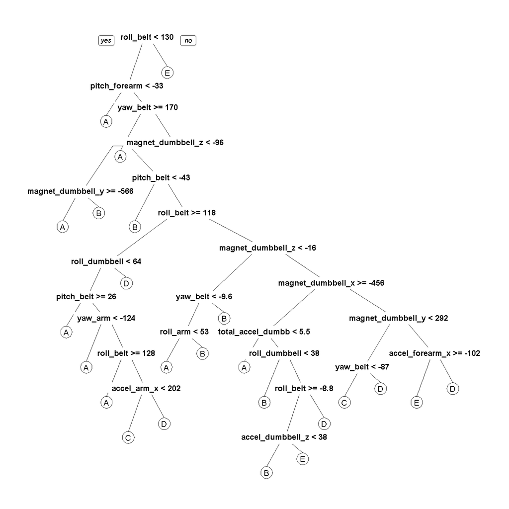

```r
classModel <- rpart(classe~., data=TrainPart, method="class")
prp(classModel)
```

In the next stage, we identify the minimum number of predictors that have significant impact to be included in the final model. As first step, eliminate any predictors with limited variability

```r
nsv <- nearZeroVar(TrainPart, saveMetrics=TRUE)
nsv
```

```
##                      freqRatio percentUnique zeroVar   nzv
## roll_belt             1.034111    8.67017663   FALSE FALSE
## pitch_belt            1.070175   13.76528533   FALSE FALSE
## yaw_belt              1.039735   14.58899457   FALSE FALSE
## total_accel_belt      1.081709    0.23777174   FALSE FALSE
## gyros_belt_x          1.049822    1.03600543   FALSE FALSE
## gyros_belt_y          1.125852    0.54347826   FALSE FALSE
## gyros_belt_z          1.086093    1.35020380   FALSE FALSE
## accel_belt_x          1.027140    1.34171196   FALSE FALSE
## accel_belt_y          1.127983    1.14639946   FALSE FALSE
## accel_belt_z          1.031481    2.42866848   FALSE FALSE
## magnet_belt_x         1.062802    2.48811141   FALSE FALSE
## magnet_belt_y         1.044888    2.42017663   FALSE FALSE
## magnet_belt_z         1.046763    3.64300272   FALSE FALSE
## roll_arm             53.289474   19.80298913   FALSE FALSE
## pitch_arm            88.043478   22.60529891   FALSE FALSE
## yaw_arm              31.640625   21.42493207   FALSE FALSE
## total_accel_arm       1.020794    0.56046196   FALSE FALSE
## gyros_arm_x           1.090909    5.19701087   FALSE FALSE
## gyros_arm_y           1.454259    3.02309783   FALSE FALSE
## gyros_arm_z           1.163009    1.96161685   FALSE FALSE
## accel_arm_x           1.020000    6.44531250   FALSE FALSE
## accel_arm_y           1.217742    4.42425272   FALSE FALSE
## accel_arm_z           1.048193    6.49626359   FALSE FALSE
## magnet_arm_x          1.040000   11.14979620   FALSE FALSE
## magnet_arm_y          1.038462    7.16711957   FALSE FALSE
## magnet_arm_z          1.088235   10.61480978   FALSE FALSE
## roll_dumbbell         1.150000   87.59341033   FALSE FALSE
## pitch_dumbbell        2.173913   85.46195652   FALSE FALSE
## yaw_dumbbell          1.314286   87.04993207   FALSE FALSE
## total_accel_dumbbell  1.069461    0.35665761   FALSE FALSE
## gyros_dumbbell_x      1.032432    1.93614130   FALSE FALSE
## gyros_dumbbell_y      1.189560    2.19089674   FALSE FALSE
## gyros_dumbbell_z      1.008000    1.68138587   FALSE FALSE
## accel_dumbbell_x      1.029703    3.36277174   FALSE FALSE
## accel_dumbbell_y      1.080537    3.77038043   FALSE FALSE
## accel_dumbbell_z      1.103448    3.35427989   FALSE FALSE
## magnet_dumbbell_x     1.019048    8.80604620   FALSE FALSE
## magnet_dumbbell_y     1.257143    6.89538043   FALSE FALSE
## magnet_dumbbell_z     1.017094    5.60461957   FALSE FALSE
## roll_forearm         12.731183   14.75033967   FALSE FALSE
## pitch_forearm        65.750000   20.83899457   FALSE FALSE
## yaw_forearm          15.363636   14.32574728   FALSE FALSE
## total_accel_forearm   1.145946    0.56895380   FALSE FALSE
## gyros_forearm_x       1.100629    2.42017663   FALSE FALSE
## gyros_forearm_y       1.004274    6.03770380   FALSE FALSE
## gyros_forearm_z       1.050847    2.40319293   FALSE FALSE
## accel_forearm_x       1.016393    6.51324728   FALSE FALSE
## accel_forearm_y       1.044776    8.30502717   FALSE FALSE
## accel_forearm_z       1.098901    4.69599185   FALSE FALSE
## magnet_forearm_x      1.041667   12.21127717   FALSE FALSE
## magnet_forearm_y      1.153846   15.31080163   FALSE FALSE
## magnet_forearm_z      1.052632   13.28974185   FALSE FALSE
## classe                1.469065    0.04245924   FALSE FALSE
```

From the output, all predictors have some variation and hence none can be eliminated. Using random forest algorithm, identify the top 15 predictors to consider.

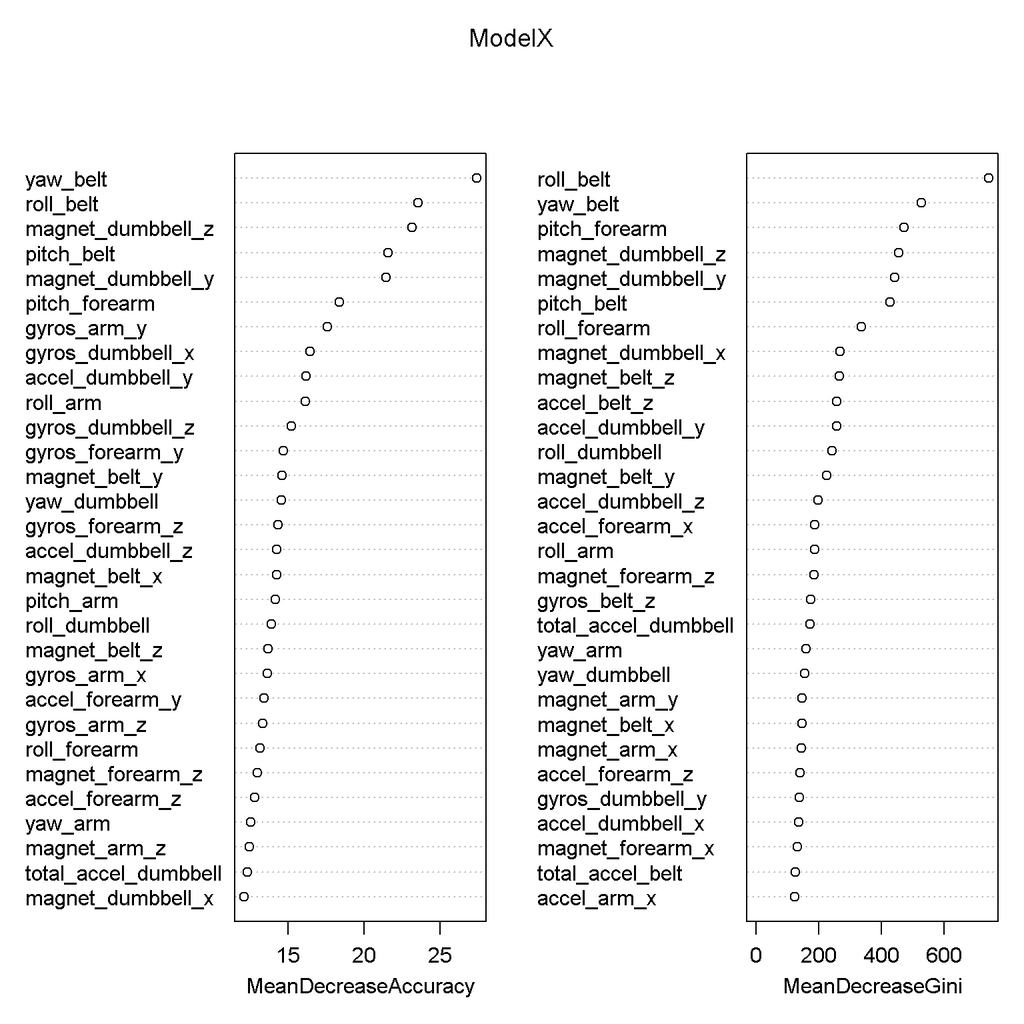

```r
set.seed(77777)
ModelX <- randomForest(classe~., data=TrainPart, importance=TRUE, ntree=100)
varImpPlot(ModelX)
```

```r
predictor_15 <- sort(importance(ModelX)[,6], decreasing=TRUE, index.return=TRUE)$ix[1:15]
names(TrainPart[,predictor_15])
```

```
##  [1] "yaw_belt"          "roll_belt"         "magnet_dumbbell_z"
##  [4] "pitch_belt"        "magnet_dumbbell_y" "pitch_forearm"
##  [7] "gyros_arm_y"       "gyros_dumbbell_x"  "accel_dumbbell_y"
## [10] "roll_arm"          "gyros_dumbbell_z"  "gyros_forearm_y"
## [13] "magnet_belt_y"     "yaw_dumbbell"      "gyros_forearm_z"
```

Determine whether any of these have strong correlation among the identified predictor set.

```r
corMatrix <- cor(TrainPart[, predictor_15] )
corMatrix[lower.tri(corMatrix, diag=TRUE)] <- 0
which(abs(corMatrix)>0.60, arr.ind=TRUE)
```

```
##                  row col
## yaw_belt           1   2
## yaw_belt           1   4
## gyros_dumbbell_x   8  11
## gyros_dumbbell_x   8  12
## gyros_dumbbell_z  11  12
## pitch_belt         4  14
## gyros_dumbbell_x   8  15
## gyros_dumbbell_z  11  15
## gyros_forearm_y   12  15
```

Note that the predictors correlations in pairs and hence elimite predictors 4, 11, 12, 14, and 15 from the top 15. Also, predictors 1 and 2, yaw_belt and roll_belt are highly correlated. However, these are the two top significant variables. Hence we will build 2 models with one of these in two seperate models and pick the better model.

```r
predictor_9 <- c(predictor_15[c(1, 3, 5:10, 13)])
corMatrix2 <- cor(TrainPart[, predictor_9] )
corMatrix2[lower.tri(corMatrix2, diag=TRUE)] <- 0
which(abs(corMatrix2) > 0.5, arr.ind=TRUE)
```

```
##      row col
```

```r
names(TrainPart[,predictor_9])
```

```
## [1] "yaw_belt"          "magnet_dumbbell_z" "magnet_dumbbell_y"
## [4] "pitch_forearm"     "gyros_arm_y"       "gyros_dumbbell_x"
## [7] "accel_dumbbell_y"  "roll_arm"          "magnet_belt_y"
```

```r
ModelA <- train(classe~yaw_belt+magnet_dumbbell_z+magnet_dumbbell_y+pitch_forearm+gyros_arm_y+gyros_dumbbell_x+accel_dumbbell_y+roll_arm+magnet_belt_y,
                  data=TrainPart,
                  method="rf",
                  trControl=trainControl(method="cv",number=2),
                  prox=TRUE,
                  verbose=TRUE,
                  allowParallel=TRUE)

saveRDS(ModelA, "F:\\coursera\\8.Practical_Machine_Learning\\pa\\modelA.Rds")

predicDataA <- predict(ModelA, newdata=TestPart)
confusionMatrixA <- confusionMatrix(predicDataA, TestPart$classe)
confusionMatrixA
```

```
## Confusion Matrix and Statistics
##
##           Reference
## Prediction    A    B    C    D    E
##          A 2220   30    3    5    1
##          B    4 1448   29    1    2
##          C    3   33 1319   35    9
##          D    5    7   16 1242   11
##          E    0    0    1    3 1419
##
## Overall Statistics
##
##                Accuracy : 0.9748
##                  95% CI : (0.971, 0.9781)
##     No Information Rate : 0.2845
##     P-Value [Acc > NIR] : < 2.2e-16
##
##                   Kappa : 0.9681
##  Mcnemar's Test P-Value : 1.632e-06
##
## Statistics by Class:
##
##                      Class: A Class: B Class: C Class: D Class: E
## Sensitivity            0.9946   0.9539   0.9642   0.9658   0.9840
## Specificity            0.9931   0.9943   0.9877   0.9941   0.9994
## Pos Pred Value         0.9827   0.9757   0.9428   0.9696   0.9972
## Neg Pred Value         0.9979   0.9890   0.9924   0.9933   0.9964
## Prevalence             0.2845   0.1935   0.1744   0.1639   0.1838
## Detection Rate         0.2829   0.1846   0.1681   0.1583   0.1809
## Detection Prevalence   0.2879   0.1891   0.1783   0.1633   0.1814
## Balanced Accuracy      0.9938   0.9741   0.9759   0.9799   0.9917
```

```r
ModelB <- train(classe~roll_belt+magnet_dumbbell_z+magnet_dumbbell_y+pitch_forearm+gyros_arm_y+gyros_dumbbell_x+accel_dumbbell_y+roll_arm+magnet_belt_y,
                  data=TrainPart,
                  method="rf",
                  trControl=trainControl(method="cv",number=2),
                  prox=TRUE,
                  verbose=TRUE,
                  allowParallel=TRUE)

saveRDS(ModelB, "F:\\coursera\\8.Practical_Machine_Learning\\pa\\modelB.Rds")

predicDataB <- predict(ModelB, newdata=TestPart)
confusionMatrixB <- confusionMatrix(predicDataB, TestPart$classe)
confusionMatrixB
```

```
## Confusion Matrix and Statistics
##
##           Reference
## Prediction    A    B    C    D    E
##          A 2217   36    1    4    2
##          B    5 1442   33    1    2
##          C    4   35 1320   54    2
##          D    6    5   13 1227   13
##          E    0    0    1    0 1423
##
## Overall Statistics
##
##                Accuracy : 0.9723
##                  95% CI : (0.9685, 0.9759)
##     No Information Rate : 0.2845
##     P-Value [Acc > NIR] : < 2.2e-16
##
##                   Kappa : 0.965
##  Mcnemar's Test P-Value : 3.124e-11
##
## Statistics by Class:
##
##                      Class: A Class: B Class: C Class: D Class: E
## Sensitivity            0.9933   0.9499   0.9649   0.9541   0.9868
## Specificity            0.9923   0.9935   0.9853   0.9944   0.9998
## Pos Pred Value         0.9810   0.9724   0.9329   0.9707   0.9993
## Neg Pred Value         0.9973   0.9881   0.9925   0.9910   0.9970
## Prevalence             0.2845   0.1935   0.1744   0.1639   0.1838
## Detection Rate         0.2826   0.1838   0.1682   0.1564   0.1814
## Detection Prevalence   0.2880   0.1890   0.1803   0.1611   0.1815
## Balanced Accuracy      0.9928   0.9717   0.9751   0.9742   0.9933
```

From the Model statistics, Model A is slightly more accurate at 97% . We will choose Model A for further verification against the independent data set for crossverification when we set out for model building.

#### Out of sample error rate

The predicted values for the 40% data set we set aside are compared against the values provided in the data set. The error rate is the ratio of incorrect prediction to total values.

```r
sum(predicDataA != TestPart$classe) / length(TestPart$classe)
```

```
## [1] 0.02523579
```

This ratio is along the expected line of 97% accuracy.

#### Submission using testing data

All the below predicted values have been found to be correct on the submission.

```r
predict(ModelA, newdata=TestData)
```

```
##  [1] B A B A A E D B A A B C B A E E A B B B
## Levels: A B C D E
```

#### Conclusion

The model summary shows that accuracy is 97%. Also, the answers for the independent testing are fully correct.

#### Reference

1. Velloso, E.; Bulling, A.; Gellersen, H.; Ugulino, W.; Fuks, H. Qualitative Activity Recognition of Weight Lifting Exercises. Proceedings of 4th International Conference in Cooperation with SIGCHI (Augmented Human ’13) . Stuttgart, Germany: ACM SIGCHI, 2013.

Read more: http://groupware.les.inf.puc-rio.br/har#weight_lifting_exercises